# Markdown & knitr

July 12, 2017

# Markdown & knitr Assignment

### Load Libraries

```r
library(lattice)
library(knitr)
library(stringr)
```

### Set Global Options

```r
opts_chunk$set(echo=TRUE,results="show",cache=TRUE)
```

### Set Directory

```r
setwd("C:/Users/hussamzarea/Desktop/Coursera/markdown/Week2")
```

### 1. Code for reading in the dataset and/or processing the data

Create a data set from the activity.csv with “,” separated columns and include the a header.

```r
activityData <- read.table("activity.csv",
                           header=TRUE,
                           sep=",",
                           stringsAsFactors = FALSE,
                           colClasses = c("numeric","Date","numeric")
                           )
```

### 2. Histogram of the total number of steps taken each day

Create a histogram of the total steps per day

- Create new data frame using the aggregate() function to total the steps per day and remove the na
- Build teh histogram

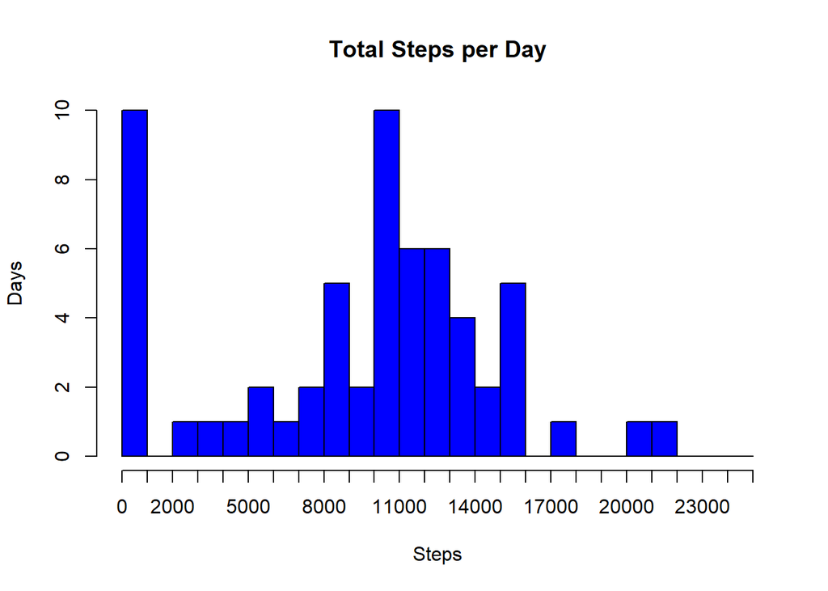

```r
#total steps
totalStepsPerDay <- aggregate(activityData$steps,
                              list(date=activityData$date),
                              sum,
                              na.rm=TRUE)

#xAxis range
xAxis = seq(from=0,to=25000,by=1000)

#histogram
hist(totalStepsPerDay$x,
     breaks = xAxis,
     main="Total Steps per Day",
     col="blue",
     xlab="Steps",
     ylab="Days",
     xaxt="n")

axis(side=1,at=xAxis,labels=xAxis)
```

### 3. Mean and median number of steps taken each day

```r
meandStepOut <- paste("Mean number of steps per day:",
                      round(mean(totalStepsPerDay$x, na.rm=T)
                            ,1)
                      )
medianStepOUt <- paste("Median number of steps per day:",
                       round(median(totalStepsPerDay$x,na.rm=T)
                             ,1)
                       )
```

#### Mean number of steps per day: 9354.2

#### Median number of steps per day: 10395

### 4. Time series plot of the average number of steps taken

First we need to create a data frame that has the average steps per interval across all days. Then can make a time series plot to see average activity rates throughout the day.

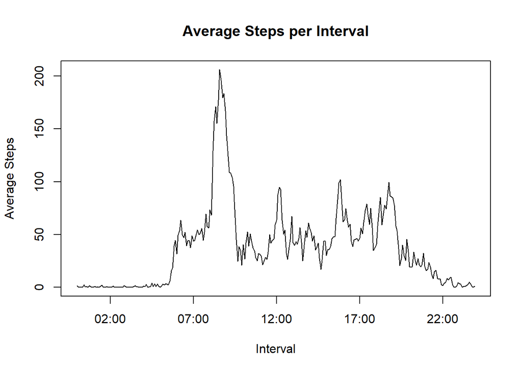

```r
#Convert the 5-minute 24-hour clock intervals.

#get the hour only by extracting only the first 2 digits
#add a leading 0 to the hour if less than 10 hour
intHours <- ifelse(activityData$interval %/% 100 < 10,
                   paste("0",activityData$interval %/% 100,
                         sep=""),
                   activityData$interval %/% 100)

#get the minut only by extracting only the first 2 digits
#add a leading 0 to the minuts if less thatn 10 minutes
intMinutes <- ifelse(activityData$interval %% 100 < 10,
                     paste("0",activityData$interval %% 100,
                           sep=""),
                     activityData$interval %% 100)

#Concatonate the hour and minute and convert to time with strptime()
intTime <- strptime(paste(intHours,
                          ":",intMinutes,
                          sep=""),
                    format="%H:%M")

timeOnly <- paste(intHours
                  ,":",
                  intMinutes,sep="")

#get the new data set
activityData <- cbind(activityData,
                      intTime)

#plot the mean number of steps for each tim
plotMean<- aggregate(activityData$steps,
                 list(intTime=activityData$intTime),
                 mean,
                 na.rm=TRUE)

plot(plotMean$intTime,plotMean$x,
     type = "l",
     main = "Average Steps per Interval",
     xlab = "Interval",
     ylab = "Average Steps")
```

```r
#get the hightest average interval
MaxStepAvg <- max(plotMean$x)
IntervalWithMaxStepAvg <- plotMean$intTime[plotMean$x == MaxStepAvg]

#remove the date from the string
IntervalWithMaxStepAvg <- str_replace_all(IntervalWithMaxStepAvg,
                                          "2017-07-12", "")
#round the hightest average
MaxStepAvg <- round(MaxStepAvg,digits=2)
```

### 5. The 5-minute interval that, on average, contains the maximum number of steps

#### The highest average occurs at 08:35:00 and is equal to 206.17 steps.

#### a. Get the number of missing data in the dataset

```r
countNAs <- sum(is.na(activityData$steps))
```

There are a total of 2304 missing values.

### 6. Code to describe and show a strategy for imputing missing data

```r
#Rename column x and merge the average into the data frame by time
names(plotMean)[names(plotMean)=="x"] <- "avgIntervalSteps"
activityDataWithAvg <- merge(x=activityData,
                             y=plotMean,by="intTime",
                             all.x=TRUE)

#Now create another column that uses the steps, if available, and the avgIntervalSteps otherwise.
activityDataWithAvg$imputedSteps <- ifelse(is.na(activityDataWithAvg$steps),
                                           activityDataWithAvg$avgIntervalSteps,
                                           activityDataWithAvg$steps)
```

### 7. Histogram of the total number of steps taken each day after missing values are imputed

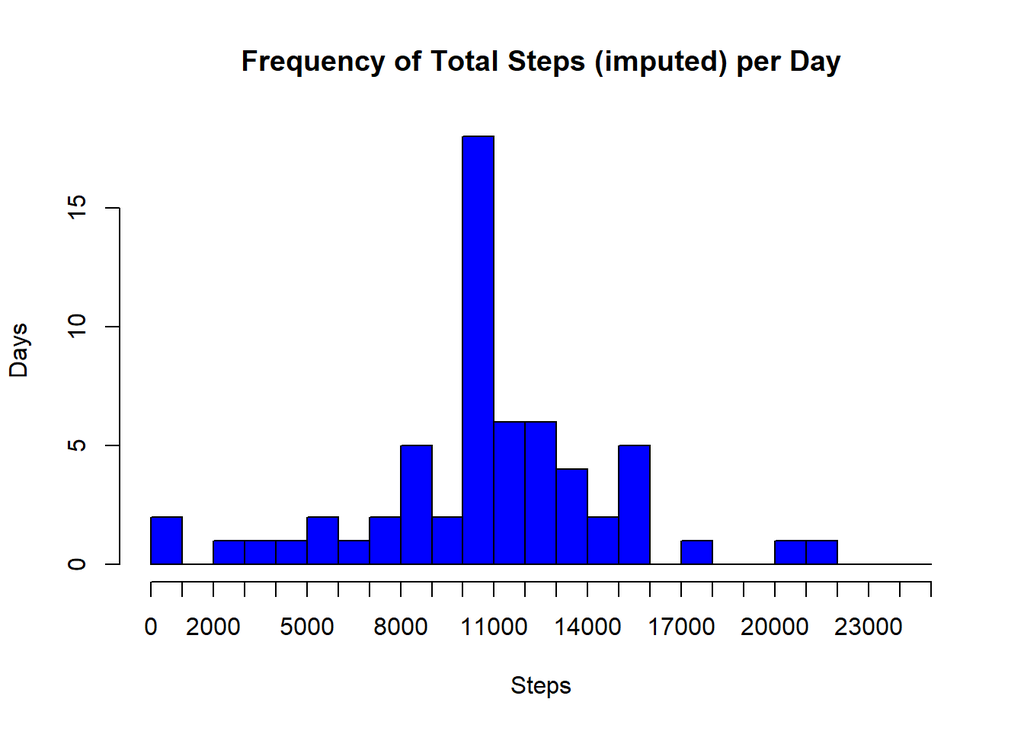

```r
totalStepsPerDayImputed <- aggregate(activityDataWithAvg$imputedSteps,list(date=activityDataWithAvg$date),sum,na.rm=TRUE)
xAxis = seq(from=0,to=25000,by=1000)
hist(totalStepsPerDayImputed$x,
      breaks = xAxis,
      main="Frequency of Total Steps (imputed) per Day",
      col="blue",
      xlab="Steps",
      ylab="Days",
      xaxt="n")

axis(side=1,at=xAxis,labels=xAxis)
```

```r
meanStepImputed <- mean(totalStepsPerDayImputed$x,na.rm=T)
medianStepImputed <- median(totalStepsPerDayImputed$x,na.rm=T)
meanStepImputedOut <- paste("Mean steps per day is",round(meanStepImputed,2))
medianStepImputedOut <- paste("Median steps per day is",round(medianStepImputed,2))
```

#### Mean steps per day is 10766.19 compared to 9354.23 from the data set with missing data

The change is due to the size of the missing data, 2304 out of 17568 is missing data. That is about 13%. Using the mean to replace the missing data is not the best option.

### 8. Panel plot comparing the average number of steps taken per 5-minute interval across weekdays and weekends

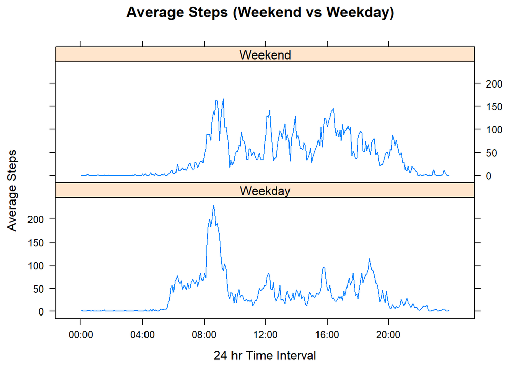

```r
activityDataWithAvg$weekday <- weekdays(activityDataWithAvg$date)
activityDataWithAvg$weekendFlag <- ifelse(activityDataWithAvg$weekday=="Saturday" | activityDataWithAvg$weekday=="Sunday",
                                          "Weekend",
                                          "Weekday")

#get the average steps ber day for weekend and weekdays
averageSteps2 <- aggregate(activityDataWithAvg$imputedSteps,
                  list(intTime=activityDataWithAvg$intTime,
                       weekendFlag=activityDataWithAvg$weekendFlag),
                  mean,
                  na.rm=TRUE)

#set up the sequence to appear on the x-axis
#(This is based on StackOverflow post 14243834)
xn <- seq(min(activityDataWithAvg$intTime),
          max(activityDataWithAvg$intTime),
          by="4 hour")

#Draw the plot with the x-axis in HH:MM format
xyplot(x~intTime|weekendFlag,
       data=averageSteps2,
       type="l",
       layout=c(1,2),
       xlab = "24 hr Time Interval",
       ylab = "Average Steps",
       main = "Average Steps (Weekend vs Weekday)",
       scales=list(
                    x=list(
                            at=xn,
                            labels=format(xn,"%H:%M")
                            )
                  )
        )
```